# DATA2902 Assignment

Author

510456760

Published

September 11, 2022

# 1 Introduction

This report analyses data from a survey addressed to students at the University of Sydney (Figure 1 ) who take *Data Analytics: Learning from Data* (DATA2x02). The survey was run from 15 August 2022 to 23 August 2022 and contains 38 questions which can be found at [this University of Sydney GitHub page](https://pages.github.sydney.edu.au/DATA2002/2022/extra/DATA2x02_survey_2022.pdf). The data can be downloaded [here](https://docs.google.com/spreadsheets/d/e/2PACX-1vTML6kYv2rDjKbPTBuSoX6bdkAWb5Hcm7IWxFmpqftgpt-AFiRhSdDn68XKjGAC_SqQHspAw78tMMuQ/pub?gid=1782171849&single=true&output=tsv). Participants found the survey on the DATA2x02 edstem page, and the survey was advertised on the DATA2x02 edstem page as well as in the DATA2x02 lectures.

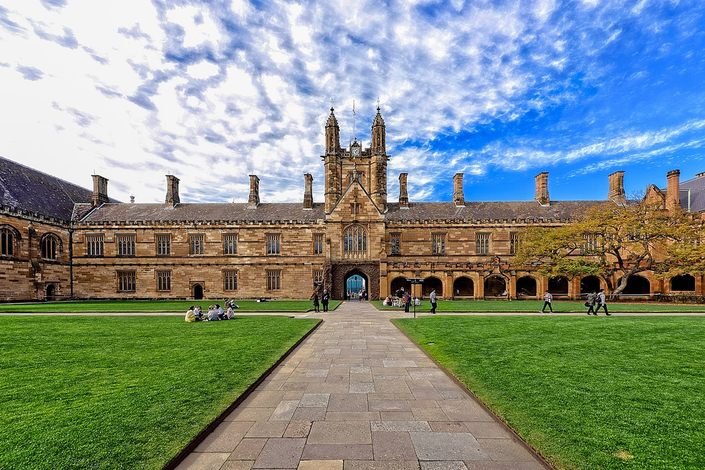

Figure 1: University of Sydney’s main quadrangle.

The cohort for DATA2x02 is split into advanced stream students who take DATA2902 and normal stream students who take DATA2002. Of the 780 students in DATA2002 and 70 students in DATA2902, responses were disproportionally recorded from 165 DATA2002 students and 40 DATA2902 students. After cleaning, responses are recorded from 120 DATA2002 students and 33 DATA2902 students.

The survey sampling was a mixture of two types of sampling:

- **Convenience sampling:** sampling via convenient sources for data. The survey sampling was convenient as it was performed via google forms and advertised through edstem and lectures.
- **Voluntary response sampling:** sampling made of up participants who have volunteered to participate.

**Bias in the DATA2x02 survey**

The survey sampling was by no means a random sample. Hence, many potential biases may arise. Some examples of biases in the survey include:

**Self-selection / non-response bias.** These forms of bias refer to people with specific characteristics who are either more likely, or less likely, to participate in surveys. Because the survey used voluntary response sampling, these biases are likely to appear.

Some variables which are most likely to be subjected to this bias include:

- **“Which unit are you enrolled in?”** as those who are proactive enough to participate are also likely proactive in their studies, or more motivated, meaning they are more likely to be in DATA2902.
- **“What kind of role (active or passive) do you think you are when working as part of a team?** as those who are proactive enough to participate in the survey are also more likely to take on an active role in a team.
- **“How much time do you usually spend on DATA2x02 each week?”** as individuals who spend more time in DATA2x02 will have allocated enough time to participate in the survey. Also, those who have spent zero hours in DATA2x02 so far will not have even noticed the survey.
- **“Do you submit assignments on time”**. Those who are proactive enough to submit their response in the survey before it is due are also more likely to submit their assignments before they are due.
- **“What is your WAM?”**. Students who respond to the survey probably spend more time on their course content and therefore likely perform better overall.
- **“How many hours a week do you spend studying?”**. Students who spend zero hours a week studying will have probably not seen the survey. Students who spend more time per week studying are more active in their course work and therefore may be more likely to respond to the survey.

The questions above are also prone to **undercoverage/advertising bias.** This bias occurs when a subgroup of a population is inadequately represented in a sample. Because the survey used convenience sampling and was advertised via lectures, individuals who participate and are proactive in their studies are more likely to be represented in the survey than those who don’t. This bias is clear in the disproportional representation of DATA2902 students over DATA2002 students in the survey results.

**Response bias.** This bias may occur when an individual feels pressured to give a certain response. Students who participated in the survey may have inflated some of their numbers to look “nicer”.

Some variables which are most likely to be influenced by this bias include:

- **“On average, how many hours each week do you spend exercising”**. Students may write down a larger number than they know to actually be true.
- **“In an average semester, how many weeks (on average, between all subjects) are you behind on lectures, labs and tutorials?”**. Students in denial may write down a smaller number than they know to actually be true.
- **“How tall are you?”**. Students (especially male students) may write down a larger number than their real height. This may also extend from measurement bias when students recorded their own heights independently.
- **“What is your WAM?”**. Students may write down a larger number than they know to actually be true.

A few questions could be improved upon to yield a better result.

**How often do you feel anxious on a daily basis?**

Scales from 0 to 10 are quite open to interpretation. This question would be improved by changing the answer scale to to a different multiple-choice selection such as:

- Never
- Rarely
- Sometimes
- Often
- Always

To generate a more objective result. The scale from 0 to 10 is mery subjective and can be interpreted in different ways.

**What is your favourite social media platform?**

Change the *text input* into a *select input*.

There is a lot of debate about what is a “real” social media platform. Anecdotally, many people seem to believe that the new social media phenomenon “BeReal” is not a social media platform, even those who use BeReal. By providing “BeReal” among others as a clear option, responders will give more accurate data.

**On average, how many hours each week do you spend exercising?**

Change the text input into a numeric slider input. This will prevent the need to clean the data by recognising inputs such as “four”, “IV”, and “4” as the same value.

**Have you ever tested positive to COVID-19?**

Remove the “Other” option. The question asks for a yes/no answer.

**How much time do you usually spend on DATA2x02 each week? …**

as well as:

**“On average, how much are you able to save per week (in AUD)?”**,

**“How many hours do you spend on social media per day?”**,

**“If you were to spend two weeks travelling around Spain, how much would you budget towards spending each day (all inclusive: accomodation / activities / food / drink / entertainment)?”**,

**“How many hours a week (on average) do you work in paid employment?”**, and

**“How many hours a week do you spend studying?”**.

Rather than allowing text input, which accepts subjective answers such as “a lot”, use a slider input

# 2 Version, Packages and Cleaning

The calculations in this report were performed in R (R Core Team 2022) within the Quarto environment (Allaire. et al. 2021) for reproducibility. Data wrangling was performed in base R and the tidyverse (Wickham et al. 2019) with a single use of naniar (Tierney 2021). Graphs were produced with ggplot2 (Wickham et al. 2019). Each code chunk in this report features `package_name::` before every non-base and non-ggplot2 function that is used.

Names of the variables were shortened. Extreme values were treated individually; either the entire entry was removed, or the extreme value was replaced with some aggregate. To conserve as much data as possible, missing values were replaced with aggregates where viable.

# 3 Aim

The aim of this report is to answer three questions:

1. *Do DATA2902 students achieve higher WAMs than DATA2002 students?*
2. *Do DATA2902 students work a different number of hours than DATA2002 students?*
3. Do DATA2902 students participate in different sports at a different proportion compared to DATA2002 students?

These questions work linearly; the results of questions two and three may provide answers to the result of question one. Before I can answer these questions, the data will need to be cleaned.

# 4 Importing Data

## 4.1 Importing Packages

This report requires packages from the `tidyverse` library.

```r
library(tidyverse)
```

## 4.2 Reading Data

The data can be read using `readr::read_tsv()` from the `readr` package.

```r
df = readr::read_tsv("../Data/DATA2x02 survey (2022) - Form responses 1.tsv")
```

| Timestamp | Have you ever tested positive to COVID-19? | What are your current living arrangements? | How tall are you? | How do you get to university? | What do you watch/listen to on the way to university? | If you were to spend two weeks travelling around Spain, how much would you budget towards spending each day (all inclusive: accomodation/activities/food/drink/entertainment)? | How do you feel about the idea of travelling overseas? | How often would you say you feel anxious on a daily basis? | How many hours a week do you spend studying? | Do you watch and/or read the news regularly? | What is your study load? | Do you work? | When you're in a Zoom lab, how often do you turn your camera on? | What is your favourite social media platform? | What is your gender? | What time did you go to sleep last night? | What time did you wake up this morning? | Pick a number at random between 0 and 9 | How do you like your steak cooked? | What is your dominant hand? | Which unit are you enrolled in? | On average, how many hours each week do you spend exercising? | How many hours a week (on average) do you work in paid employment? | What city and suburb do you currently reside in? | On average, how much are you able to save per week (in AUD)? | In an average week during the semester, do you make an hourly plan of your day? | In an average semester, how many weeks (on average, between all subjects) are you behind on lectures, labs and tutorials? | Do you submit assignments on time? | Have you ever used R before starting DATA2x02? | … |
| --- | --- | --- | --- | --- | --- | --- | --- | --- | --- | --- | --- | --- | --- | --- | --- | --- | --- | --- | --- | --- | --- | --- | --- | --- | --- | --- | --- | --- | --- | --- |
| 15/08/2022 15:28:42 | No | With parent(s) and/or sibling(s) | 1,58 | I never travel to campus | I never travel to campus | 50-100USD | 10 | 3 | 44 | Sometimes | Full time | Part time | Never | youtube | female | 02:00:00 | 07:30:00 | 7 | Rare | Right | DATA2002 | 24.0 | 10.0 | china | NA | 1-3 days | 1.0 | Always | No | … |
| 15/08/2022 15:30:12 | Yes | College or student accomodation | 165 | Bus, Walk | Music, YouTube | 100 | 4 | 8 | 35 | Sometimes | Full time | I don't currently work | Never | Twitter | Non-binary | 06:00:00 | 11:00:00 | 3 | Medium-rare | Right | DATA2002 | 2.0 | 0.0 | Redfern | 50 | Never | 1.0 | Always | Yes | … |
| 15/08/2022 15:31:59 | Yes | Share house | 180 | Walk | Music | $700 | 7 | 8 | 14 | Sometimes | Full time | Part time | Some of the time | WeChat | male | 02:00:00 | 08:20:00 | 6 | Medium | Right | DATA2002 | 4.0 | 20.0 | Sydney Ultimo | 100 | 1-3 days | 2.0 | Sometimes | Yes | … |
| 15/08/2022 15:33:26 | Yes | With parent(s) and/or sibling(s) | 182 | Train, Walk | Music, YouTube, Lecture recordings | 200 | 10 | 2 | 8 | No | Full time | Casual | Never | Instagram | Male | 00:00:00 | 07:40:00 | 1 | Medium-rare | Right | DATA2902 | 4.0 | 11.0 | Hornsby | 300 | 1-3 days | 0.0 | Always | Yes | … |
| 15/08/2022 15:35:30 | Yes | With parent(s) and/or sibling(s) | 173 | Train | Music, Podcasts | 5 | 7 | 2 | 6 | Sometimes | Full time | Casual | Never | pornhub | NA | 11:30:00 | 09:30:00 | 4 | Medium-rare | Right | DATA2902 | 8.0 | 10.0 | Sydney, Waverton | 300 | Never | 0.0 | Always | Yes | … |
| 15/08/2022 15:35:52 | No | With parent(s) and/or sibling(s) | 163 | Bus | Music | dont know | 2 | 10 | 3 | Sometimes | Full time | Part time | Never | twitter | female | 01:00:00 | 09:00:00 | 5 | Medium-rare | Right | DATA2002 | 0.0 | 21.0 | cherrybrook | 350 | Never | 4.0 | Usually | Yes | … |
| 15/08/2022 15:37:09 | No | Share house | 183cm | Bus | I don't watch or listen to anything on the way to university | 2000 | 5 | 6 | 40 | Sometimes | Full time | Casual | Never | Discord | male | 01:24:00 | 07:22:00 | 6 | Medium-well done | Right | DATA2902 | 1.0 | 0.0 | Waterloo | 0 | Never | 1.0 | Always | Yes | … |
| 15/08/2022 15:38:33 | Yes | With partner | 6'3" | Walk | I don't watch or listen to anything on the way to university, Music | 150 | 9 | 3 | 20 | Sometimes | Full time | Casual | Never | tik tok | male | 22:00:00 | 03:15:00 | 7 | Medium-rare | Right | DATA2002 | 6.0 | 15.0 | Sydney, Chippendale | 100 | 1-3 days | 3.0 | Usually | Yes | … |
| 15/08/2022 15:39:35 | No | With parent(s) and/or sibling(s) | 166 | Train | I don't watch or listen to anything on the way to university | on average 150 dollars | 10 | 6 | 50 | Sometimes | Full time | Casual | Some of the time | wechat | female | 23:00:00 | 08:00:00 | 8 | Medium | Right | DATA2002 | 5.0 | 11.0 | NA | 200 | Always | 2.0 | Always | Yes | … |
| 15/08/2022 15:44:02 | Yes | With parent(s) and/or sibling(s) | 165 | Train, Bus, Walk | Music, YouTube, Lecture recordings | 3000 | 8 | 4 | 3 | Sometimes | Full time | Casual | Only in breakout rooms | Instagram | Female | 23:30:00 | 05:55:00 | 9 | I don't eat beef | Right | DATA2002 | 3.0 | 15.0 | Parramatta | 350 | Never | 8.0 | Usually | Yes | … |

[output cut: 197 more lines]

# 5 Data Processing Steps

Before I can analyse any of the data, the data needs to be cleaned. Before I can clean any of the data, the columns need to be renamed using Tarr (2022) . However, since I only care about money saved, WAM, unit enrolment, study hours, and sports, many of the columns are unnecessary and would otherwise cluster the report, so I will also subset the data only for the columns that are related to my questions.

Note that there is also no simple way to uniquely identify each column. The `timestamp` option could be used, but it is not impossible that two people submitted their surveys at the exact same time. Hence, an `identifier` column will be added, following the footsteps of Tarr (2022) .

```r
old_names = colnames(df)
new_names = c("timestamp","covid_positive","living_arrangements","height","uni_travel_method","uni_travel_listen","spain_budget","feel_overseas","feel_anxious","study_hrs","read_news","study_load","work","lab_zoom","social_media","gender","sleep_time","wake_time","random_number","steak_preference","dominant_hand","normal_advanced","exercise_hrs","employment_hrs","city","weekly_saving","hourly_plan","weeks_behind","assignment_on_time","used_r_before","team_role","data2x02_hrs","social_media_hrs","uni_year","sport","wam","shoe_size","decade_selection")

# overwrite the old names with the new names:
colnames(df) = new_names

# combine old and new into a data frame:
name_combo = dplyr::bind_cols(New = new_names, Old = old_names)
important_vars = c("timestamp", "study_hrs", "study_load", "work", "normal_advanced", "exercise_hrs", "employment_hrs", "weekly_saving", "data2x02_hrs", "sport", "wam")
name_combo |>
  dplyr::filter(name_combo$New %in% important_vars) |>
  gt::gt()
```

| New | Old |
| --- | --- |
| timestamp | Timestamp |
| study_hrs | How many hours a week do you spend studying? |
| study_load | What is your study load? |
| work | Do you work? |
| normal_advanced | Which unit are you enrolled in? |
| exercise_hrs | On average, how many hours each week do you spend exercising? |
| employment_hrs | How many hours a week (on average) do you work in paid employment? |
| weekly_saving | On average, how much are you able to save per week (in AUD)? |
| data2x02_hrs | How much time do you usually spend on DATA2x02 each week? |
| sport | Which sports do you play most often? |
| wam | What is your WAM? |

```r
# subset dataframe and create unique identifier for each entry
df = df |>
  dplyr::mutate(identifier = row_number()) |>
  subset(select=c("identifier", important_vars[important_vars != "timestamp"]))
```

## 5.1 Cleaning - Absurd Responses

Before I can deal with any `NA` values, I first need to deal with absurd (i.e. obviously false) responses. The simplest method to detect any absurd responses in the quantitative sections is to construct a histogram of the data. Consider the histograms in Figure 2 :

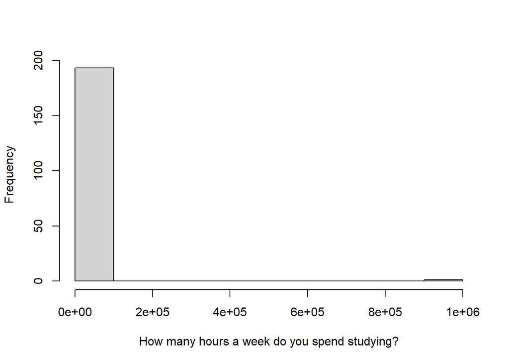

(a)

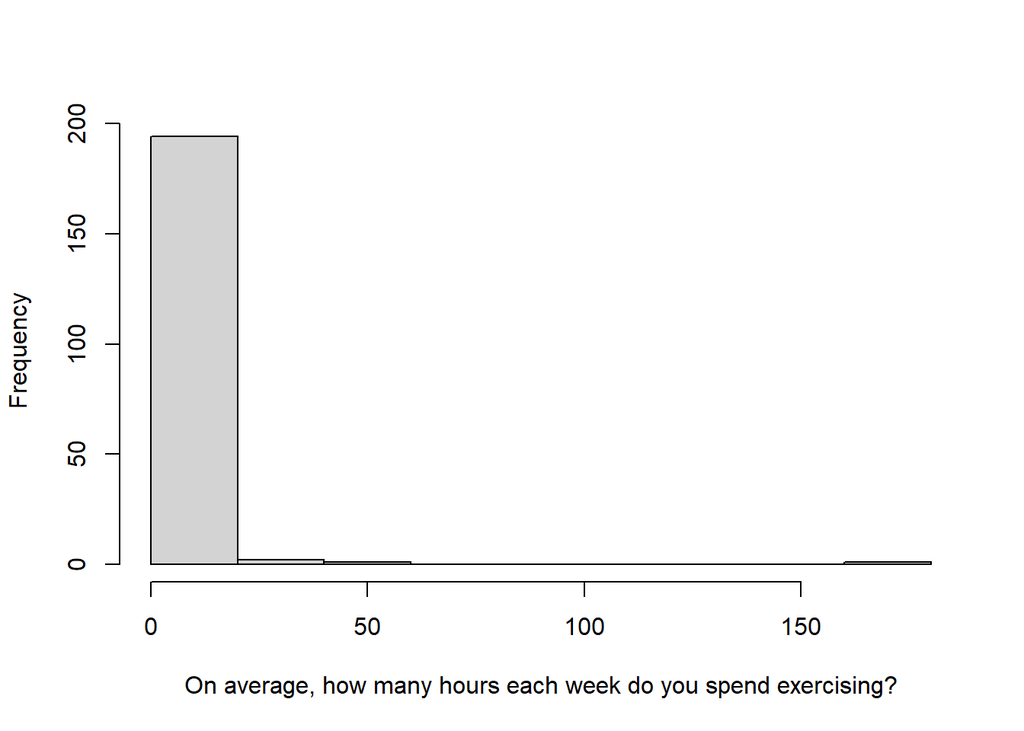

(b)

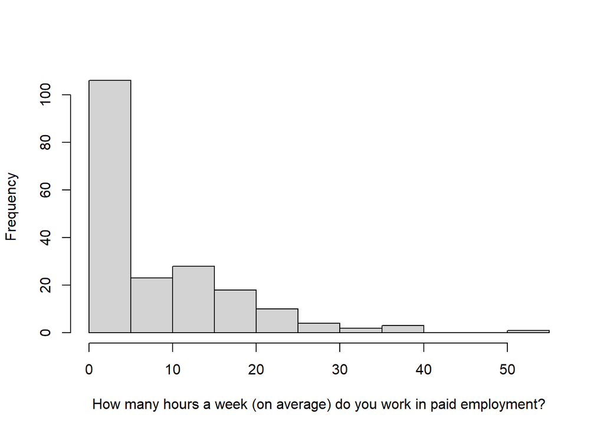

(c)

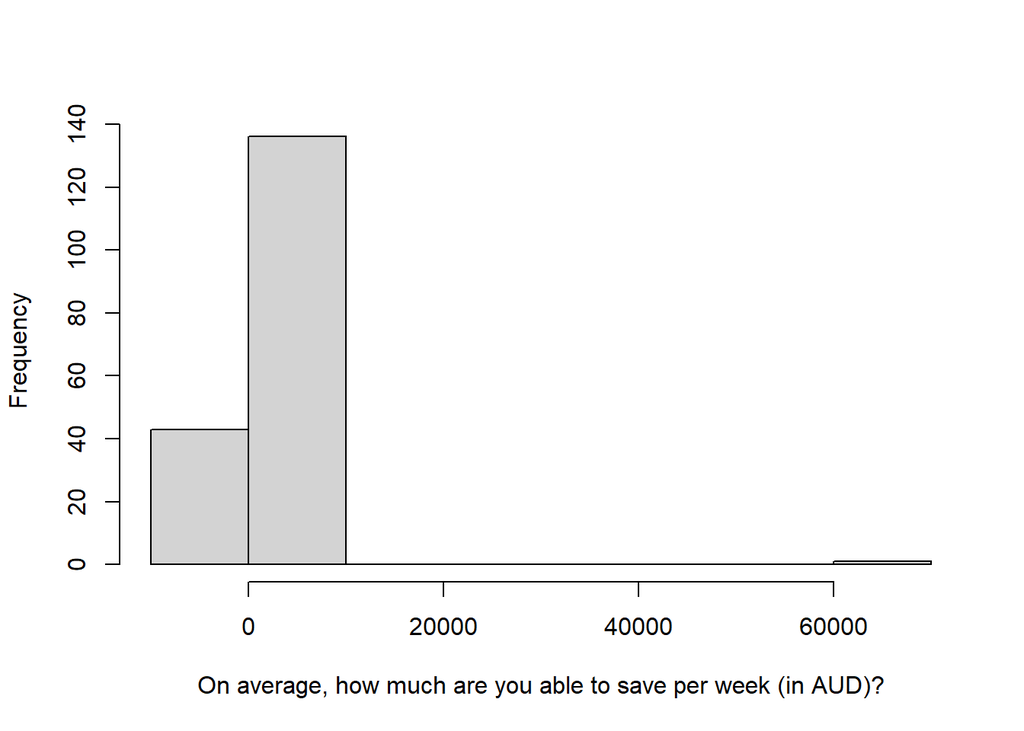

(d)

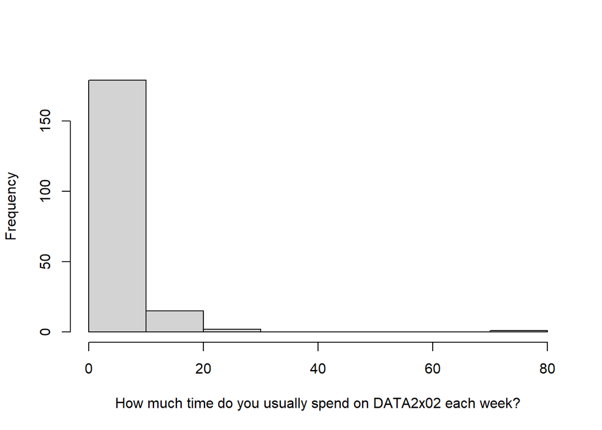

(e)

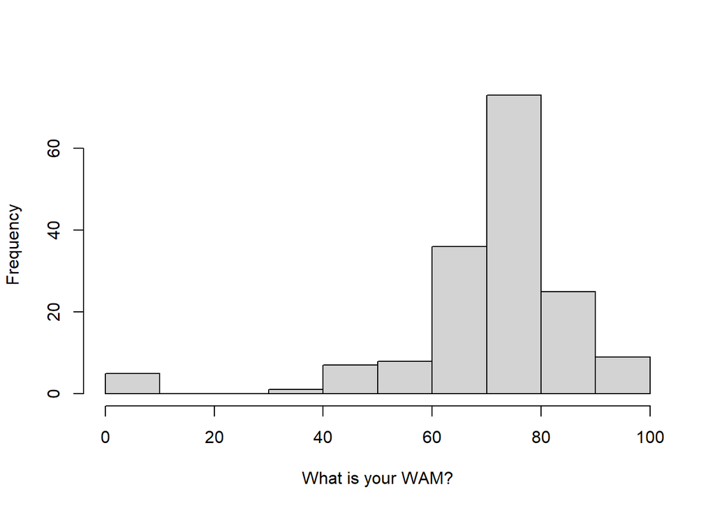

(f)

Figure 2: Histograms of Quantitative Variables in DATA2x02 Survey

```r
graphics::hist(df$study_hrs, main="", xlab=as.character(name_combo[name_combo$New == "study_hrs",2]))
graphics::hist(df$exercise_hrs, main="", xlab=as.character(name_combo[name_combo$New == "exercise_hrs",2]))
graphics::hist(df$employment_hrs, main="", xlab=as.character(name_combo[name_combo$New == "employment_hrs",2]))
graphics::hist(df$weekly_saving, main="", xlab=as.character(name_combo[name_combo$New == "weekly_saving",2]))
graphics::hist(df$data2x02_hrs, main="", xlab=as.character(name_combo[name_combo$New == "data2x02_hrs",2]))
graphics::hist(df$wam, main="", xlab=as.character(name_combo[name_combo$New == "wam",2]))
```

| identifier | study_hrs | study_load | work | normal_advanced | exercise_hrs | employment_hrs | weekly_saving | data2x02_hrs | sport | wam |
| --- | --- | --- | --- | --- | --- | --- | --- | --- | --- | --- |
| 69 | 1e+06 | Full time | I don't currently work | DATA2002 | 6 | 0 | 0 | 7 | basketball | 55 |

Ignoring their false `study_hrs` input, this row seems completely normal, so I’ll just replace the study_hours value with an NA value and treat it later on with the other NA values.

```r
df <- naniar::replace_with_na(df, replace = list(study_hrs = 1e+06))
```

A similar process is applied to each of the other variables:

- **`exercise_hrs:`** filtering for individuals with more than 50 hours spent exercising gives two abnormal results:

  | identifier | study_hrs | study_load | work | normal_advanced | exercise_hrs | employment_hrs | weekly_saving | data2x02_hrs | sport | wam |
  | --- | --- | --- | --- | --- | --- | --- | --- | --- | --- | --- |
  | 15 | 60 | Full time | Part time | DATA2002 | 168 | 2 | 100 | 10 | Table tennis | 80 |
  | 155 | 10 | Full time | Casual | DATA2002 | 52 | 24 | 300 | 2 | Soccer | 69 |

  - The result with 168 hours spent exercising seems fairly average if we ignore `exercise_hours` , so I will replace their exercise_hrs entry with `NA`.
  - The result with 52 hours spent exercising also has a WAM of 69 and a gender of “attack helicopter” Tarr (2022) . This entire row will be removed by filtering.

  ```r
  df <- df |>
    dplyr::mutate(exercise_hrs = replace(exercise_hrs, exercise_hrs==168, NA))

  df <- df |>
    dplyr::filter(!(identifier == "155"))
  ```

- **`employment_hrs:`** A closer investigation on the row with greater than 50 employment hours gives fairly realistic results, including fewer study hours and more weekly savings to accommodate for the lager number of employment hours. Hence, this row will not be mutated.

  | identifier | study_hrs | study_load | work | normal_advanced | exercise_hrs | employment_hrs | weekly_saving | data2x02_hrs | sport | wam |
  | --- | --- | --- | --- | --- | --- | --- | --- | --- | --- | --- |
  | 77 | 30 | Full time | Part time | DATA2002 | 6 | 55 | 1500 | 8 | Swimming | 80 |

- **`weekly_saving:`** Looking at the rows containing a weekly saving of more than 1000 AUD per week, we see two outliers (ignoring the value of 1500 which was explored above) with obviously false results.

  | identifier | study_hrs | study_load | work | normal_advanced | exercise_hrs | employment_hrs | weekly_saving | data2x02_hrs | sport | wam |
  | --- | --- | --- | --- | --- | --- | --- | --- | --- | --- | --- |
  | 17 | 5 | Full time | Casual | DATA2002 | 7 | 25 | 69420 | 7 | Running | 75 |
  | 77 | 30 | Full time | Part time | DATA2002 | 6 | 55 | 1500 | 8 | Swimming | 80 |
  | 187 | 18 | Full time | Full time | DATA2902 | 14 | 20 | 4023 | 78 | Soccer, Netball, Cricket, Tennis, Volleyball, Table tennis, Rugby, Golf, Swimming, Rowing, NRL, AFL, I don't play any sport, Singing | 1 |

  ```r
  df <- df |>
    dplyr::filter(identifier != "11") |>
    dplyr::filter(identifier != "187")
  ```

  Note that the `187` identifier was the only outlier in the distribution for DATA2x02 study hours, so we do not need to remove any more outliers from `data2x02_hrs`.
- **`wam:`** many entries gave a WAM that is less than 50. The entries with a WAM of `34.0` and `45.0` appear relatively normal otherwise, so I’ll leave those. The entries with a WAM that is less than `10.0` are very unlikely, yet the rest of these rows appear normal, so I will just replace the WAMs that are less than `10.0` with `NA` values.

  ```r
  df <- df |>
    dplyr::mutate(wam = replace(wam, wam<10, NA))
  ```

## 5.2 Cleaning - NAs

We can use the `visdat` package to find any NA values in the data.

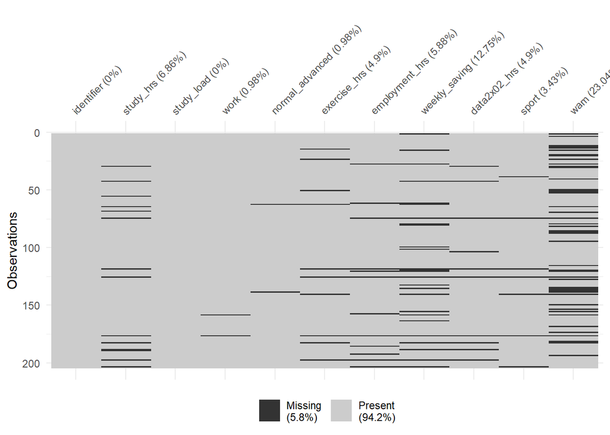

```r
visdat::vis_miss(df)
```

### 5.2.1 NAs in Employment

First I need to deal with any potential `NA` values in the employment categories (work, employment_hrs, weekly_saving). Each category will be dealt with uniquely.

- **`work:`** Let’s first look at the `NA` values in this column.

  | identifier | study_hrs | study_load | work | normal_advanced | exercise_hrs | employment_hrs | weekly_saving | data2x02_hrs | sport | wam |
  | --- | --- | --- | --- | --- | --- | --- | --- | --- | --- | --- |
  | 160 | 35 | Full time | NA | DATA2002 | 7 | 0 | NA | 6 | I don't play any sport | NA |
  | 178 | NA | Full time | NA | DATA2902 | NA | NA | NA | NA | NA | NA |

  We see that:
  - One row contains an `NA` value for `work`, but has defined `employment_hrs` as 0. I will replace the `work` value here with “I don’t currently work”.
  - On the other hand, the second entry consists of mostly `NA` values and will be removed.

  ```r
  df <- df |>
    # Replace work value with "I don't currently work" if 0 employment_hours and
    # work is NA.
    dplyr::mutate(work = dplyr::if_else(
      is.na(work) & employment_hrs == 0,
      true="I don't currently work",
      false=work)) |>
    # Filter to remove rows which contain NA values for work and employment_hrs
    dplyr::filter(!(is.na(work) & is.na(employment_hrs)))
  ```

  Similarly, looking at the “I don’t currently work” category in `work`, some individuals have written nonzero values for `employment_hrs`.

  | identifier | work | employment_hrs |
  | --- | --- | --- |
  | 21 | I don't currently work | 6 |
  | 35 | I don't currently work | 1 |
  | 37 | I don't currently work | 2 |
  | 115 | I don't currently work | 10 |
  | 175 | I don't currently work | 2 |

  These values will be replaced with zeroes.

  ```r
  df <- df |>
    dplyr::mutate(employment_hrs = dplyr::if_else(
      work=="I don't currently work",
      true=0,
      false=employment_hrs)
    )
  ```

- **`employment_hrs:`** Now I need to treat the NA values in `employment_hrs`. If there is an `NA` in `employment_hrs`, then I will replace the `employment_hrs` value with the average value in the row’s given `work` category.

  ```r
  df <- df |>
    dplyr::mutate(employment_hrs = dplyr::case_when(
      is.na(employment_hrs) & work == "Full time" ~ sapply(df[df$work=="Full time",
                                                         "employment_hrs"],
                                                         mean,
                                                         na.rm = TRUE
                                                      ),
      is.na(employment_hrs) & work == "Part time" ~ sapply(df[df$work=="Part time",
                                                         "employment_hrs"],
                                                         mean,
                                                         na.rm = TRUE
                                                      ),
      is.na(employment_hrs) & work == "Casual" ~ sapply(df[df$work=="Casual",
                                                         "employment_hrs"],
                                                        mean,
                                                        na.rm = TRUE
                                                      ),
      is.na(employment_hrs) & work == "Self employed" ~ sapply(df[df$work=="Self employed",
                                                         "employment_hrs"],
                                                         mean,
                                                         na.rm = TRUE
                                                      ),
      is.na(employment_hrs) & work == "Contractor" ~ sapply(df[df$work=="Contractor",
                                                         "employment_hrs"],
                                                         mean,
                                                         na.rm = TRUE
                                                      ),
      is.na(employment_hrs) & work == "I don't currently work" ~ sapply(df[df$work=="I don't currently work",
                                                         "employment_hrs"],
                                                         mean,
                                                         na.rm = TRUE
                                                      ),
      TRUE ~ employment_hrs
      )
    )
  ```

- **`weekly_saving:`** Finally, I need to clean the NAs in the `weekly_saving` category. If there is an `NA` in `weekly_saving`, then I will replace the `weekly_saving`value with the average value in the row’s given `work` category.

  ```r
  df <- df |>
    dplyr::mutate(weekly_saving = dplyr::case_when(
      is.na(weekly_saving) & work == "Full time" ~ sapply(df[df$work=="Full time",
                                                         "weekly_saving"],
                                                         mean,
                                                         na.rm = TRUE
                                                      ),
      is.na(weekly_saving) & work == "Part time" ~ sapply(df[df$work=="Part time",
                                                         "weekly_saving"],
                                                         mean,
                                                         na.rm = TRUE
                                                      ),
      is.na(weekly_saving) & work == "Casual" ~ sapply(df[df$work=="Casual",
                                                         "weekly_saving"],
                                                        mean,
                                                        na.rm = TRUE
                                                      ),
      is.na(weekly_saving) & work == "Self employed" ~ sapply(df[df$work=="Self employed",
                                                         "weekly_saving"],
                                                         mean,
                                                         na.rm = TRUE
                                                      ),
      is.na(weekly_saving) & work == "Contractor" ~ sapply(df[df$work=="Contractor",
                                                         "weekly_saving"],
                                                         mean,
                                                         na.rm = TRUE
                                                      ),
      is.na(weekly_saving) & work == "I don't currently work" ~ sapply(df[df$work=="I don't currently work",
                                                         "weekly_saving"],
                                                         mean,
                                                         na.rm = TRUE
                                                      ),
      TRUE ~ weekly_saving
      )
    )
  ```

  Even after this, there is one missing value from identifier `81`, which is the only individual who is a contractor and hence the mean is undefined. Since they have written 0 employment hours, then I will assign their weekly savings the same value as the mean of the savings in the group with zero employment hours.

  ```r
  df[df$work=="Contractor","weekly_saving"] = sapply(df[df$employment_hrs == 0, "weekly_saving"], mean, na.rm=TRUE)
  ```

### 5.2.2 NAs in Study

Now I need to deal with any potential `NA` values in the study categories (study_hrs, study_load, normal_advanced, data2x02_hrs, wam). Each category will be dealt with uniquely.

- **`study_hrs:`** given that there are no `NA` values in the study_load column, I will replace NAs in `study_hrs` with the average value for `study_hrs` in their given `study_load` category.

  ```r
  df <- df |>
    dplyr::mutate(study_hrs = dplyr::case_when(
      is.na(study_hrs) & study_load == "Full time" ~ sapply(df[df$study_load=="Full time",
                                                         "study_hrs"],
                                                         mean,
                                                         na.rm = TRUE
                                                      ),
      is.na(study_hrs) & study_load == "Part time" ~ sapply(df[df$study_load=="Part time",
                                                         "study_hrs"],
                                                         mean,
                                                         na.rm = TRUE
                                                      ),
      TRUE ~ study_hrs
      )
    )
  ```

- **`normal_advanced:`** the `NA` values in this categorical variable make up just 1% of the values in `normal_advanced`. Hence, I will just remove these values from the dataframe.

  ```r
  df <- df |>
    dplyr::filter(!is.na(normal_advanced))
  ```

- **`data2x02_hrs:`** it can be assumed that the number of hours spent on DATA2x02 is proportional to the total number of study hours, and that the proportion is roughly equal for all students. The mean proportion of data2x02_hrs / study_hrs is equal to 0.3865292.

  ```r
  prop_data2x02 = sapply(df[df$study_hrs != 0,"data2x02_hrs"]/df[df$study_hrs != 0, "study_hrs"], mean, na.rm=TRUE)

  df <- df |>
    dplyr::mutate(data2x02_hrs = dplyr::if_else(is.na(data2x02_hrs), true=prop_data2x02*study_hrs, false=data2x02_hrs))
  ```

- **`wam:`** this variable is difficult to predict based on the data given, so rows containing `NA` values here will be removed from the dataframe.

  ```r
  df <- df |>
    dplyr::filter(!is.na(wam))
  ```

### 5.2.3 NAs in Sport

There are only a few NA values in the sport section.

- **`sport:`** let’s take a look at the NAs in this column.

  | identifier | study_hrs | study_load | work | normal_advanced | exercise_hrs | employment_hrs | weekly_saving | data2x02_hrs | sport | wam |
  | --- | --- | --- | --- | --- | --- | --- | --- | --- | --- | --- |
  | 39 | 12.00000 | Full time | Casual | DATA2002 | 6 | 15 | 350.00 | 6.0000 | NA | 75.98 |
  | 119 | 25.30055 | Full time | I don't currently work | DATA2002 | NA | 0 | 84.48 | 9.7794 | NA | 70.00 |
  | 206 | 25.30055 | Full time | I don't currently work | DATA2002 | 1 | 0 | 84.48 | 10.0000 | NA | 77.00 |

  We can assume these NA values to mean “I don’t play any sport”.

  ```r
  df <- df |>
    dplyr::mutate(sport = tidyr::replace_na(sport, "I Don't Play any Sport"))
  ```

- **`exercise_hrs:`** let’s look at the NAs in this column.

  ```r
  dplyr::filter(df, is.na(exercise_hrs))
  ```

  | identifier | study_hrs | study_load | work | normal_advanced | exercise_hrs | employment_hrs | weekly_saving | data2x02_hrs | sport | wam |
  | --- | --- | --- | --- | --- | --- | --- | --- | --- | --- | --- |
  | 15 | 60.00000 | Full time | Part time | DATA2002 | NA | 2 | 100.00 | 10.0000 | Table tennis | 80 |
  | 119 | 25.30055 | Full time | I don't currently work | DATA2002 | NA | 0 | 84.48 | 9.7794 | I Don't Play any Sport | 70 |
  | 200 | 25.30055 | Full time | I don't currently work | DATA2002 | NA | 0 | 84.48 | 9.7794 | Tennis, badminton | 80 |

  These NAs are too complex to predict. Hence, I will remove them from the dataframe.

  ```r
  df <- df |>
    dplyr::filter(!is.na(exercise_hrs))
  ```

# 6 Hypothesis Tests

Recall the questions that this report intends to address.

1. *Do DATA2902 students achieve higher WAMs than DATA2002 students?*
2. *Do DATA2902 students work a different number of hours than DATA2002 students?*
3. Do DATA2902 students participate in different sports at a different proportion compared to DATA2002 students?

Each of these questions need to be investigated using a different test. I will be analysing data from the `wam`, `employment_hrs`, and `sport` columns in the dataframe.

## 6.1 1. Do *DATA2902* students achieve statistically higher WAMS than *DATA2002* students at the p < 0.05 level?

Some interesting comparisons can be made between the DATA2902 students and the DATA2002 students. Before the more nuanced comparisons can be made, we need to compare DATA2902 and DATA2002 students using their most fundamental difference: results in previous units of study.

Sydney University’s most general statistic used to quantify results in previous units of study is the Weighted Average Mark (WAM). Hence, the main aim of this report is to clarify whether there is a statistically significant difference in WAM between DATA2902 and DATA2002 students. In particular, we are interested in whether DATA2902 students generally outperform DATA2002 students or not.

Across both the DATA2902 cohort and DATA2002 cohort, the distribution of WAM is not normal, as we can see by looking at the qqplots (Figure 3 ). In both the DATA2002 qqplot and DATA2902 qqplot, the endpoints begin to diverge from the qqplot, though the deviation is more significant in DATA2002.

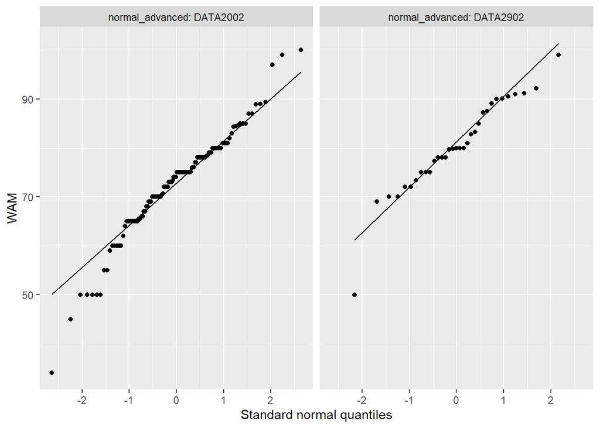

Figure 3: qqplot of students’ WAM

```r
df |>
  ggplot() +
  aes(sample = wam) +
  geom_qq() +
  geom_qq_line() +
  facet_grid(cols= vars(normal_advanced), labeller = "label_both") +
  labs(x="Standard normal quantiles", y="WAM")
```

The data in both cohorts is, however, reasonably symmetric. This can be seen in the density histograms in Figure 4 .

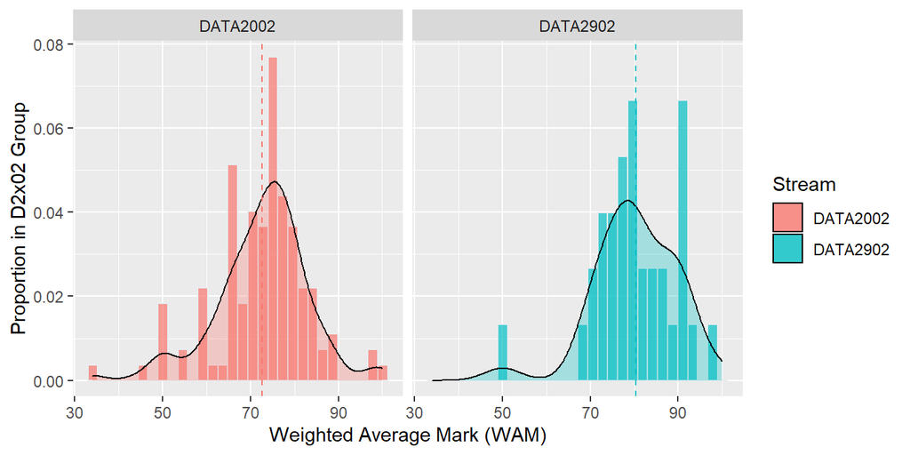

Figure 4: Histogram of students’ WAM

```r
# Define vector for filling each histogram based on normal_advanced value
colors = rep(0,length(df$normal_advanced))
colors[df$normal_advanced == "DATA2902"] = 'red'
colors[df$normal_advanced == "DATA2002"] = 'blue'

# Define dataframe containing average wam of DATA2902 and DATA2002 students
avg_2x02 <- plyr::ddply(df, "normal_advanced", summarise, avg=mean(wam))

# Produce histograms. All functions below are from the ggplot2 package.
df |>
  ggplot(aes(x=wam, fill=normal_advanced)) +
  geom_histogram(aes(y = ..density..),
                 color="#e9ecef",
                 alpha=0.7,
                ) +
  geom_density(alpha=0.3) +
  geom_vline(data=avg_2x02, aes(xintercept=avg, color=normal_advanced),
             linetype="dashed") +
  facet_grid(cols = vars(normal_advanced)) +
  labs(x="Weighted Average Mark (WAM)", y="Proportion in D2x02 Group", fill="Stream") +
  guides(color=FALSE)
```

We are saved by the Central Limit Theorem here, as there is a large enough sample size of 33 DATA2902 students and 120 DATA2002 students. Therefore, I use a two-sample t-test test

Lets first look at the mean, standard deviation, and sample size of each group (Table 1 ).

```r
summary_df = df |>
  dplyr::group_by(normal_advanced) |>
  dplyr::summarise(Mean = mean(wam), SD = sd(wam), n=n())

knitr::kable(summary_df)
```

Table 1: Summary statistics for WAM across the two DATA2x02 streams.

| normal_advanced | Mean | SD | n |
| --- | --- | --- | --- |
| DATA2002 | 72.68125 | 10.477077 | 120 |
| DATA2902 | 80.36513 | 9.331357 | 33 |

It appears that DATA2902 students achieve higher WAMs with less spread than DATA2002 students. Lets check that this is not purely due to chance with the two-sample t-test.

```r
d2902_wam = unlist(df[df$normal_advanced == "DATA2902", "wam"])
d2002_wam = unlist(df[df$normal_advanced == "DATA2002", "wam"])

# Looks at d2902_wam - d2002_wam
t_test = stats::t.test(d2902_wam, d2002_wam, alternative="greater", paired=FALSE, var.equal=FALSE, correct=FALSE, conf.level = 0.95)
```

1. **Hypothesis:** Let $\mu_\text{Adv}$ be the mean WAM of *DATA2902* students, and $\mu_\text{Nml}$ be the mean WAM of *DATA2002* students. The null hypothesis is $H_0: \mu_\text{Adv} = \mu_\text{Nml}$ and the alternative hypothesis $H_1: \mu_\text{Adv} > \mu_\text{Nml}$.
2. **Assumptions:** the two population means follow a normal distribution and are roughly symmetric (Figure 4 ). The populations are identically distributed and sampling is performed independently.
3. **Test statistic:** $t_0 = \frac{\mu_\text{Adv} - \mu_\text{Nml}}{\sqrt{\frac{\sigma^2_\text{Adv}}{n_\text{Adv}}+\frac{\sigma^2_\text{Nml}}{n_\text{Nml}}}}$ where $\mu_\text{Adv}=$ 80.4, $\mu_\text{Nml} = $ 72.7, $\sigma_\text{Adv} =$ 9.33, $\sigma_\text{Nml} =$ 10.5, $n_\text{Adv} =$ 33, and $n_\text{Nml} =$ 120.
4. **Observed test statistic:** $t_0=$ 4.08
5. **p-value:** $P(t_{151}\leq$ 4.08 $) < 0.0001$
6. **Decision:** Since the p-value is less than 0.05, we reject the null hypothesis in favour of the alternative hypothesis. Hence, we conclude that *DATA2902* students achieve a higher WAM than *DATA2002* students, on average.

## 6.2 2. Are hours worked statistically different at the p < 0.05 level between *DATA2902* and *DATA2002* students?

Why do DATA2902 students perform better than DATA2002 students across all of their classes? Could there be any other factors influencing these results?

One possibility is that DATA2902 students have a greater work ethic than DATA2002 students, which would imply a positive correlation between *WAM* and *Employment Hours*.

Another possibility is that the advanced stream students do not work as much as the normal stream students, and hence spent more time studying.

We can attempt to visualize a correlation by looking at the data among those who do work, as in Figure 5 .

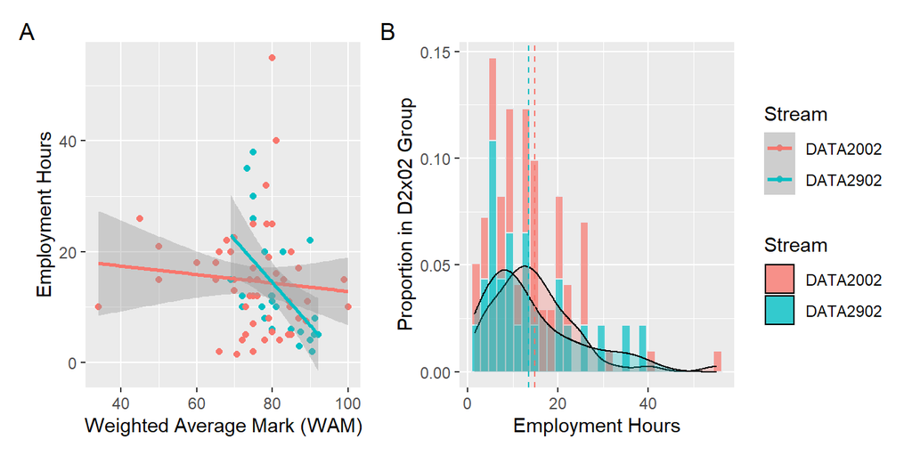

Figure 5: (A) Scatter Plot of WAM and Employment Hours and (B) Histogram of Employment Hours

```r
df_work <- df |>
  dplyr::filter(employment_hrs != 0)

# Define vector for filling each histogram based on normal_advanced value
colors = rep(0,length(df_work$normal_advanced))
colors[df_work$normal_advanced == "DATA2902"] = 'red'
colors[df_work$normal_advanced == "DATA2002"] = 'blue'

# Define dataframe containing average employment hours of DATA2902 and DATA2002 students
avg_2x02 <- plyr::ddply(df_work, "normal_advanced", summarise, avg=mean(employment_hrs))

# Produce
p1 <- ggplot(df_work) +
  # add the aesthetics
  aes(x = wam,
      y = employment_hrs,
      colour = normal_advanced) +
  # add a geometry
  geom_point() +
  geom_smooth(method='lm') +
  # tidy up the labels
  labs(x = "Weighted Average Mark (WAM)",
       y = "Employment Hours",
       colour = "Stream")


# Produce histograms. All functions below are from the ggplot2 package.
p2 <- ggplot(df_work) +
  aes(x=employment_hrs, fill=normal_advanced) +
  geom_histogram(aes(y = ..density..),
                 color="#e9ecef",
                 alpha=0.7,
                ) +
  geom_density(alpha=0.3) +
  geom_vline(data=avg_2x02, aes(xintercept=avg, color=normal_advanced),
             linetype="dashed") +
  labs(x="Employment Hours", y="Proportion in D2x02 Group", fill = "Stream") +
  guides(color=FALSE)

# requires "patchwork" package
library(patchwork)
p1 + p2 + patchwork::plot_layout(guides = 'collect') +
  patchwork::plot_annotation(tag_levels = 'A')
```

```r
x = df[df$normal_advanced == "DATA2902",]$employment_hrs
y = df[df$normal_advanced == "DATA2002",]$employment_hrs
r = rank(c(x, y))
w_sum = c("W" = sum(r[1:length(x)]))
min_w = length(x)*(length(x)+1)/2

p_val = 2*stats::pwilcox(w_sum - min_w - 1, length(x), length(y), lower.tail=FALSE)
```

1. **Hypothesis:** Let $\mu_\text{Adv}$ be the mean hours worked for *DATA2902* students, and $\mu_\text{Nml}$ be the mean hours worked for *DATA2002* students. The null hypothesis is $H_0: \mu_\text{Adv} = \mu_\text{Nml}$ and the alternative hypothesis $H_1: \mu_\text{Adv} \neq \mu_\text{Nml}$.
2. **Assumptions:** the two populations are independent and follow the same distribution but differ by a shift (Figure 5 ).
3. **Test statistic:** $W = R_1 + R_2 +\ ...\ + R_{33}$ where $R_i\in \text{ranks}(X_\text{Adv})$. Under $H_0$, $W$ follows the $WRS(n_\text{Adv}, n_\text{Nml})$ distribution.
4. **Observed test statistic:** $w=$ 3021.5
5. **p-value:** $2P(W\geq$ 3021.5 $) =$ 0.033 $< 0.05$
6. **Decision:** Since the p-value is less than 0.05, we reject the null hypothesis in favour of the alternative hypothesis. Hence, we conclude that *DATA2902* students do not work the same number of hours as *DATA2002* students. Moreover, Table 2 shows that *DATA2902* students work more hours than *DATA2902* hours, on average.

```r
summary_df = df |>
  dplyr::group_by(normal_advanced) |>
  dplyr::summarise(Mean = mean(employment_hrs), SD = sd(employment_hrs), n=n())

knitr::kable(summary_df)
```

Table 2: Summary statistics for employment hours across the two DATA2x02 streams.

| normal_advanced | Mean | SD | n |
| --- | --- | --- | --- |
| DATA2002 | 6.891667 | 9.842282 | 120 |
| DATA2902 | 10.166667 | 10.466216 | 33 |

## 6.3 3. Do DATA2902 students participate in different sports at a statistically different proportion compared to DATA2002 students?

The previous result informs us that the success of DATA2902 students could be explained by a greater work ethic. If such a statement is true, does this greater work ethic also come paired with a different sport preference? Could the better results of DATA2902 be explained by a more unique sport lifestyle? While the latter cannot be definitively confirmed by this study, as many other confounding variables may also be involved, we can certainly address the prior.

Before we perform a hypothesis test on the data, we need to investigate some of the data at hand. Hence, we produce a contingency table for each sport among DATA2x02 students (Table 3 ) using some code from Tarr (2022) .

```r
sport <- df |>
  dplyr::select(identifier, sport, normal_advanced) |>
  tidyr::separate_rows(sport,
                       sep = ", ") |>
  # Combine categories that appear only once into "Other"
  dplyr::mutate(sport = tools::toTitleCase(sport),
                sport = factor(sport),
                sport = forcats::fct_lump_min(sport, 2))

cont_table = table(sport$normal_advanced, sport$sport)
knitr::kable(cont_table)
```

|  | AFL | Badminton | Basketball | Bouldering | Cricket | Frisbee | Golf | Gym | I Don’t Play any Sport | Netball | Pool | Rowing | Rugby | Running | Soccer | Swimming | Table Tennis | Tennis | Volleyball | Other |
| --- | --- | --- | --- | --- | --- | --- | --- | --- | --- | --- | --- | --- | --- | --- | --- | --- | --- | --- | --- | --- |
| DATA2002 | 2 | 8 | 11 | 1 | 2 | 2 | 6 | 2 | 31 | 3 | 1 | 4 | 1 | 5 | 16 | 24 | 15 | 14 | 4 | 14 |
| DATA2902 | 0 | 1 | 3 | 3 | 4 | 0 | 2 | 0 | 10 | 1 | 1 | 0 | 1 | 1 | 5 | 6 | 3 | 5 | 1 | 4 |

This contingency table can be extended to a more visual bar chart (Figure 6 ) for each of the groups of students by using code from Tarr (2022) . Visually, it appears that the distributions for the number of participants in each sport is approximately the same in both the *DATA2902* and *DATA2002* class.

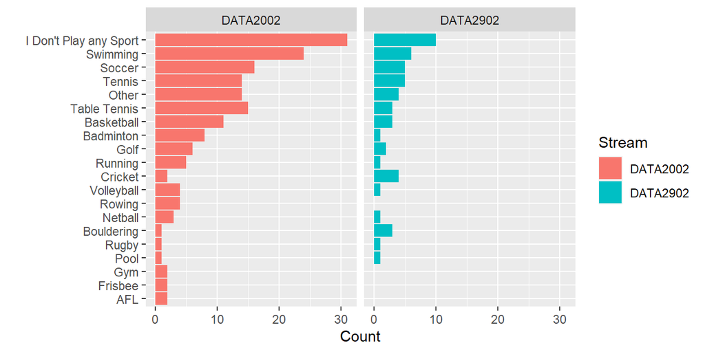

Figure 6: Bar charts of students’ sport choices

```r
sport <- df %>%
  dplyr::select(identifier, sport, normal_advanced) %>%
  tidyr::separate_rows(sport,
                       sep = ", ") %>%
  dplyr::mutate(sport = tools::toTitleCase(sport),
                sport = factor(sport),
                sport = forcats::fct_lump_min(sport, 2))

sport %>%
  ggplot() +
  aes(y = reorder(sport, sport, function(x) length(x)), fill=normal_advanced) +
  geom_bar() +
  facet_grid(cols = vars(normal_advanced)) +
  labs(y = "", x = "Count", fill="Stream")
```

As many of the entries in this table contain values that are less than five, I will use a Monte Carlo permutation test.

```r
set.seed(2022)
sport_data = as.matrix(cont_table)
chi_test = stats::chisq.test(sport_data, simulate.p.value=TRUE, B=10000)
```

1. **Hypothesis:** $H_0: p_{ij} = p_{\bullet j} = y_{\bullet j}/n$ and $H_1: p_{ij}\neq p_{\bullet j}$.
2. **Assumptions:** the observations are exchangeable. This is justified via the random assignment in the Monte Carlo test.
3. **Test statistic:** $t_0 = \displaystyle\sum^2_i\sum^{20}_j\frac{(y_{ij}-e_{ij})^2}{e_{ij}} \not\sim \chi^2_{20}$ as some cell counts are less than 5.
4. **Observed test statistic:** $t_0 =$ 18.6 .
5. **p-value:** $P(T \geq t_0) = \frac{n(T\geq t_0)}{n_\text{total}} =$ 0.481 $\geq 0.05$.
6. **Decision:** Since the p-value is greater than 0.05, we cannot reject the null hypothesis in favour of the alternative hypothesis. Indeed, Figure 6 confirms that the proportion of students who participate in each sport across *DATA2902* and *DATA2002* is roughly equal.

# 7 Results

Despite all of the cleaning and analysis above, there is still one elephant in the room; the DATA2x02 students who responded to the survey are not representative of the entire DATA2002 cohort. This opens the conclusions drawn in this report to be influenced by many biases, such as non-response/self-selection bias which inherently induces an under-coverage of the DATA2x02 cohort.

Fortunately, it appears as if these biases have not had a large impact on factors such as WAM. For example, the average WAM across the entire responding cohort is 74 which is approximately equal to the current average WAM at the University of Sydney (see [this](https://imgur.com/a/TFZzTZv) semester average mark distribution across the USYD faculty of engineering in 2018).

Moreover, while these biases may have had a net impact over the entire cohort of responders, by comparing and contrasting the summary statistics of two groups of responders, we reduce the potential impact of any bias. Hence, the aim of this report still has integrity in stating that:

1. DATA2902 students perform better, on average, than DATA2002 students,
2. DATA2902 students work more, on average, than DATA2002 students,
3. DATA2902 students and DATA2002 students participate in the same sports in equal proportions.

It is worthwhile to note that while the above is probably true on average across the entire DATA2x02 cohort, it cannot reliably be used on an individual level, even if we were to ignore the ethical boundaries of such an action. For example, suppose that you did choose to compare a random DATA2902 student to a random DATA2002 student via WAM.

```r
n=100

set.seed(2022)

rand_n_D2902 = sample(unlist(df[df$normal_advanced == "DATA2902", "wam"]), size=n, replace=TRUE)
rand_n_D2002 = sample(unlist(df[df$normal_advanced == "DATA2002", "wam"]), size=n, replace=TRUE)

sum(rand_n_D2902 > rand_n_D2002) / n
```

The percentage of the time that the DATA2902 has a higher WAM is 0.75 which is by no means statistically significant.

## 8 References

Allaire., J. J., Christophe Dervieux., Carlos Scheidegger., Charles Teague, and Yihui Xie. 2021. “Quarto.” 2021. https://quarto.org/.

R Core Team. 2022. “R: A Language and Environment for Statistical Computing.” Vienna, Austria: R Foundation for Statistical Computing. June 23, 2022. https://www.R-project.org/.

Tarr, Garth. 2022. “Data2002 Project: Data Importing and Cleaning Guide.” August 26, 2022. https://pages.github.sydney.edu.au/DATA2002/2022/report/report_data.html.

Tierney, Nicholas. 2021. “Getting Started with Naniar.” 2021. https://cran.r-project.org/web/packages/naniar/vignettes/getting-started-w-naniar.html.

Wickham, Hadley, Mara Averick, Jennifer Bryan, Winston Chang, Lucy D’Agostino McGowan, Romain François, and et al Garrett Grolemund. 2019. “Welcome to the Tidyverse.” Journal of Open Source Software. 2019. https://doi.org/10.21105/joss.01686.